# R Notebook

# Loading and inspecting the data

Run the chunk below to pre-load and format some data that you’ll be using for the activity below. Feel free to review the individual steps (**hint:** they’re similar to the transformations we applied in Module 1), but otherwise we’ll jump right into inspecting and working with the data!

```r
pson_pca_logtpm_mat_file <- file.path(data_dir, "pson_pca_logtpm_mat.RData")
if (!file.exists(pson_pca_logtpm_mat_file)) {
  load(file.path(data_dir, "pson_brca_expr_tpm_df.RData"))
  load(file.path(data_dir, "pson_expr_gene_info.RData"))
  pson_expr_tpm_df2 <- merge(x = gene_df, y = pson_expr_tpm_df,
                      by.x = "gene_id", by.y = "gene_id")
  pson_tpm_mat <- as.matrix(pson_expr_tpm_df2[, -c(1:5)])
  rownames(pson_tpm_mat) <- pson_expr_tpm_df2$symbol
  pson_logtpm_mat <- log2(1 + pson_tpm_mat)
  pson_pca_mat<-t(pson_logtpm_mat)
  save(pson_pca_mat, file = pson_pca_logtpm_mat_file)
} else {
  load(pson_pca_logtpm_mat_file)
}
```

Check out `pson_expr_tpm_df`:

```r
#Andrew taught us many ways to inspect the data. Try this one.
View(pson_expr_tpm_df[1:1000, ]) # only view the first 1000 rows so we don't
                                 # make your browser too unhappy...
```

As you learned, the gene IDs are not very informative — they come from a database called **Ensembl**. More commonly, we would use the **Hugo gene symbols** (https://www.genenames.org/). These are the gene names you are more used to seeing (MYC, BRCA1, etc). We have this information stored in another file.

Check out the first few rows of `gene_df`:

```r
#head(gene_df)
convert_ENSG_HUGO_df<-gene_df[, c(1,3)]
head(convert_ENSG_HUGO_df)
```

|  | gene_id | symbol |
| --- | --- | --- |
| 1 | ENSG00000000003 | TSPAN6 |
| 2 | ENSG00000000005 | TNMD |
| 3 | ENSG00000000419 | DPM1 |
| 4 | ENSG00000000457 | SCYL3 |
| 5 | ENSG00000000460 | C1orf112 |
| 6 | ENSG00000000938 | FGR |

We now have a new variable called `pson_pca_mat` that we’ll use for the examples below. Take a look at the first few rows and columns of this matrix, and try to figure out what changes were made to go from `pson_expr_tpm_df` and `gene_df` to what you see. Compare to `pson_logtpm_mat` and see what else is different.

```r
# command here
pson_pca_mat[1:5, 1:5]
```

```
           TSPAN6 TNMD     DPM1    SCYL3 C1orf112
mRNA_R17 5.111031    0 7.413289 1.510962 2.750607
mRNA_R21 5.526695    0 7.032101 1.510962 3.683696
mRNA_R20 5.336997    0 7.055933 1.469886 3.480265
mRNA_R19 5.194166    0 6.842099 1.550901 3.361768
mRNA_R18 5.048759    0 6.958495 1.722466 3.460743
```

```r
pson_logtpm_mat[1:5, 1:5]
```

```
         mRNA_R17 mRNA_R21 mRNA_R20 mRNA_R19 mRNA_R18
TSPAN6   5.111031 5.526695 5.336997 5.194166 5.048759
TNMD     0.000000 0.000000 0.000000 0.000000 0.000000
DPM1     7.413289 7.032101 7.055933 6.842099 6.958495
SCYL3    1.510962 1.510962 1.469886 1.550901 1.722466
C1orf112 2.750607 3.683696 3.480265 3.361768 3.460743
```

Besides any normalization (e.g., “log” of expression values), translation (changing gene IDs to symbols), or format conversion (data frame to matrix), we’ve also **transposed** or rotated the data such that genes are now represented by columns and samples by rows. More on why we did this next!

# Getting started with PCA with PS-ON cell line data

We will use the function **`prcomp()`** to run the principal component analysis (PCA) algorithm. We’re interested in checking out the variability and similarity of samples (cell lines) in our data based on their gene expression patterns. To do this, we need to give `prcomp()` a matrix as where the samples are the *rows*, and the features (transcript counts) are the *columns*. If we hadn’t transposed, PCA would still work — but it would instead be telling us about the relationship *between* genes.

## Calculating PCA

We want to make sure that we can connect our expression data to motility measurements. I happen to know that for one sample in `pson_pca_mat`, we’re missing motility data (I cheating a bit and checked in advance, but it makes life easier given our time constraints).

```r
missing_row
```

```
[1] 8
```

As described in our lecture, there are two additional things for us to consider:

- 1. The data should be mean-centered around 0.
- 2. The data should be scaled so that the standard deviation for each gene is 1.

Our features have the same units, and it is often the case that they are not scaled; this is somewhat subjective. “prcomp()” automatically mean-centers the data for us. Scaling is up to us.

```r
pson_pca <- prcomp(pson_pca_mat, scale = FALSE)
```

Exciting, right? But now we can get to our exploratory analysis. What goodies does PCA_PSON hold for us?

```r
names(pson_pca)
```

```
[1] "sdev"     "rotation" "center"   "scale"    "x"
```

We discussed these in the lecture. To summarize: “sdev”: The standard deviation of the principal components “rotation”: The matrix of feature loadings (weights) “center”: The feature means that prcomp() subtracted from each feature “scale”: The feature standard deviations used in scaling “x”: Coordinates of the cell lines projected onto the principal components

```r
dim(pson_pca$sdev)
```

```r
dim(pson_pca$rotation)
```

```
[1] 18682    62
```

```r
dim(pson_pca$center)
```

```r
dim(pson_pca$scale)
```

```r
dim(pson_pca$x)
```

```
[1] 62 62
```

Are these dimensions what you would expect?

```r
pson_pca$rotation[1:5, 1:5]
```

```
                   PC1           PC2           PC3           PC4           PC5
TSPAN6    1.584158e-04 -4.610167e-03  5.191321e-03  3.180007e-03  1.729562e-02
TNMD      2.753341e-05  1.197326e-05 -2.777844e-06 -2.525294e-05  1.860216e-06
DPM1     -5.799012e-04 -1.316543e-03  7.183747e-03 -6.022465e-04 -1.600115e-03
SCYL3    -2.893989e-03  1.230555e-02 -1.404974e-03  7.094512e-04 -2.288287e-03
C1orf112 -2.880724e-03  1.562732e-03  9.381906e-04  1.681514e-03  2.043382e-03
```

```r
pson_pca$x[1:5,1:5]
```

```
               PC1       PC2       PC3         PC4      PC5
mRNA_R17 -39.74973 -76.79247  6.395282  -1.5573725 34.99499
mRNA_R21 -44.31163 -70.45641 16.540568  -5.2920620 50.47853
mRNA_R20 -45.41556 -80.75207  9.007610  -0.0308181 42.11339
mRNA_R19 -42.46163 -73.68480 13.031576  -3.3063448 45.94905
mRNA_R18 -37.95296 -62.22346 19.415076 -10.2662479 43.98570
```

```r
length(pson_pca$sdev)
```

```
[1] 62
```

```r
length(pson_pca$center)
```

```
[1] 18682
```

```r
length(pson_pca$scale)
```

```
[1] 1
```

Check the values out! Why does scale have length 1?

Has PCA reduced the dimensionality of our data? Let’s examine the importance of the principal components by ploting the percentage of variance explained.

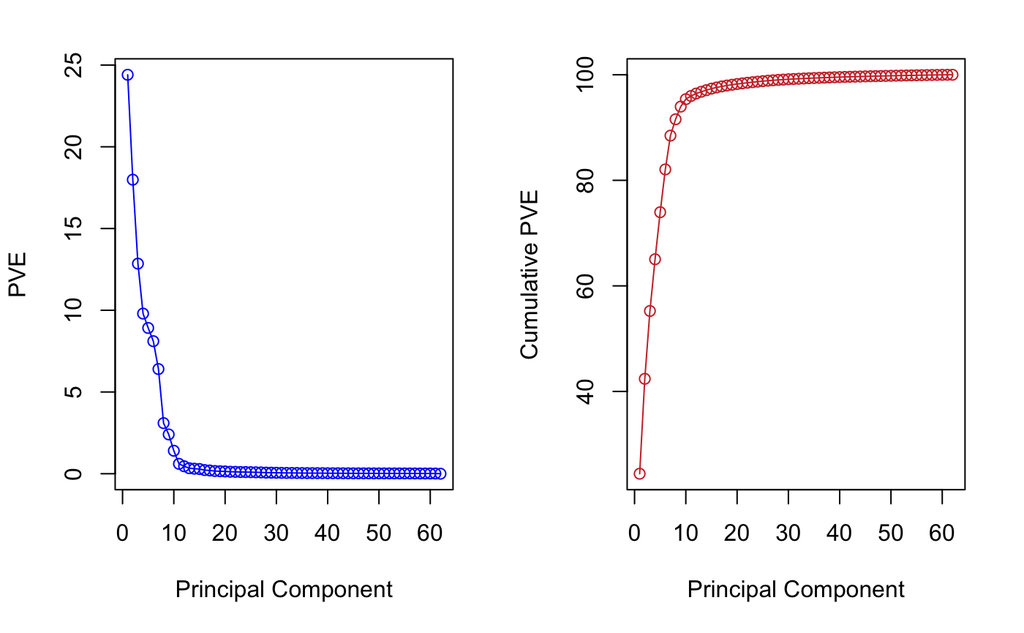

```r
pve <- 100 * pson_pca$sdev^2 / sum(pson_pca$sdev^2)
par(mfrow = c(1, 2))
plot(pve,
  type = "o",
  ylab = "PVE", xlab = "Principal Component", col = "blue"
)
plot(cumsum(pve),
  type = "o",
  ylab = "Cumulative PVE", xlab = "Principal Component", col = "brown3"
)
```

## Visualizing patterns and groups with PCA

The first two PCs account for a lot of the variance, > 40%. The first 10 PCs account for almost all of the variance. Let’s see if the first two PCs, PC1 and PC2, reveal any patterns in our data.

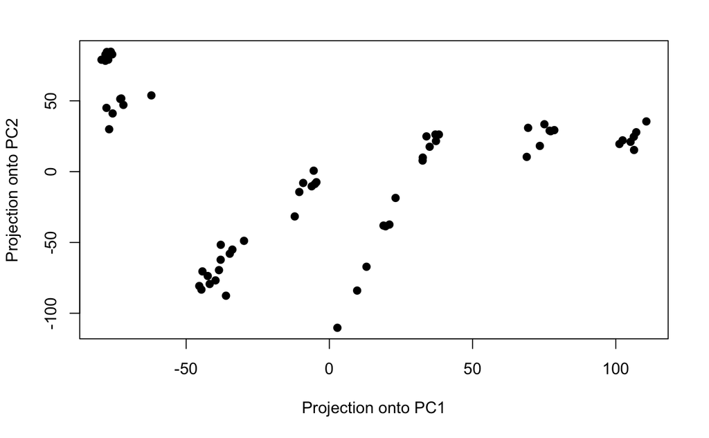

```r
plot(pson_pca$x[, 1:2],
  pch = 19,
  xlab = "Projection onto PC1", ylab = "Projection onto PC2"
)
```

Each point gives the coordinates of a sample/cell line in PC space. It’s a nice pattern with some potential. Does is have meaning for our data set? Let’s color the points by cell line type and diagnosis.

```r
cell_speeds_df <- subset(pson_motil_tidy_df, summary_metric == "speed_um_hr")
names(cell_speeds_df)
```

```
 [1] "id_motil"                      "summary_metric"
 [3] "average_value"                 "standard_deviation"
 [5] "standard_error"                "total_number_of_cells_tracked"
 [7] "sample"                        "id_expr"
 [9] "diagnosis"                     "cellType"
[11] "catalogNumber"                 "cellLine"
[13] "experimentalCondition"         "stiffness"
[15] "stiffness_units"               "surface"
[17] "laminate"                      "organ"
[19] "tumorType"                     "stiffness_norm"
[21] "average_value_scaled"
```

We will color by “`cellLine`” and “`diagnosis`”, and it is possible to explore other relationships as well.

Here is a simple function for coloring points by type:

```r
color_by_type <- function(vec) {
  nn <- length(unique(vec))
  cols <- rainbow(nn,start = 0,end = max(1, nn - 1) / nn)

  return(cols[as.numeric(as.factor(vec))])
}
```

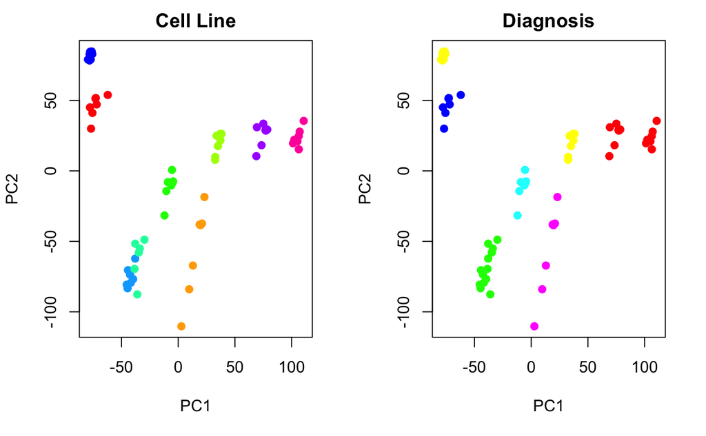

```r
par(mfrow = c(1, 2))
plot(pson_pca$x[, c(1, 2)],
  col = color_by_type(cell_speeds_df$cellLine),
  main = "Cell Line", pch = 19
)
plot(pson_pca$x[, c(1, 2)],
  col = color_by_type(cell_speeds_df$diagnosis),
  main = "Diagnosis", pch = 19
)
```

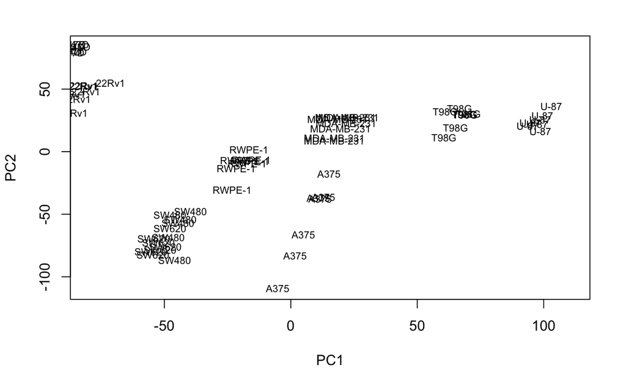

```r
plot(pson_pca$x[, c(1, 2)], pch = ".", cex = 0)
text(pson_pca$x[, c(1, 2)], labels = cell_speeds_df$cellLine, pos = 2, cex = 0.7)
```

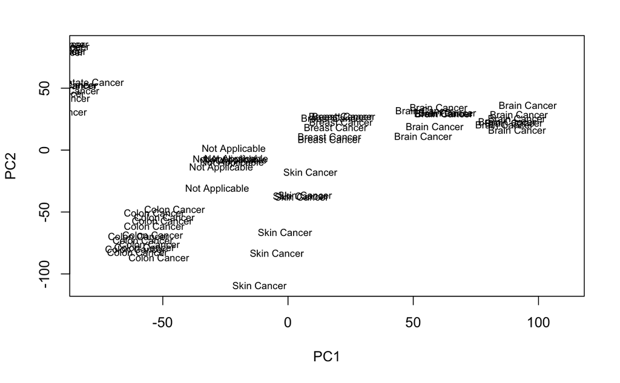

```r
plot(pson_pca$x[, c(1, 2)], pch = ".", cex = 0)
text(pson_pca$x[, c(1, 2)], labels = cell_speeds_df$diagnosis, pos = 2, cex = 0.7)
```

We can perform additional principal components analyses on cell line specific data.